# FM: - Week2 - Assignment

Thanasit C.

2024-01-24

## Week2: Assignment

### 1. Packages

install.packages(“ggplot2”)  
install.packages(“tidyverse”)  
install.packages(“readxl”)  
install.packages(“dplyr”)  
install.packages(“ggpubr”)

### 2. Libraries

```r
library(ggplot2)
library(tidyverse)
library(readxl)
library(dplyr)
library(ggpubr)
```

### 3. Set working directory

```r
setwd("/Users/sieng/Documents/Study/MS.Business Analytics/SPRING 2024/Fundamental of Machine Learning/Assignment")
```

### 4. Import data [Top 50 stocks in The Stock Exchange of Thailand: SET50]

source: https://www.set.or.th/en/market/index/set50/overview

```r
set50df <- read_excel("FML - Week2 - Assignment - dataset - SET50.xlsx") %>% as.data.frame()
str(set50df)
```

```
## 'data.frame':    50 obs. of  12 variables:
##  $ Symbol           : chr  "ADVANC" "AOT" "AWC" "BANPU" ...
##  $ Open             : num  215 59.5 3.86 6.45 145.5 ...
##  $ High             : num  216 60.2 3.9 6.5 146 ...
##  $ Low              : num  214 58.8 3.7 6.3 144 ...
##  $ Last             : num  215 59.2 3.7 6.4 145 ...
##  $ Change           : num  -1 -0.75 -0.14 -0.05 0.5 -0.25 -0.1 -0.5 -4 -0.15 ...
##  $ % Change         : num  -0.46 -1.25 -3.65 -0.78 0.35 -0.91 -1.34 -1.92 -1.65 -2.21 ...
##  $ Bid              : num  214 59 3.7 6.35 145 ...
##  $ Offer            : num  215 59.25 3.72 6.4 145.5 ...
##  $ Volume (Shares)  : num  3001980 41491404 61651594 74371081 6859175 ...
##  $ Value ('000 Baht): num  645788 2470185 232305 475369 993894 ...
##  $ Industry         : chr  "Technology" "Services" "Property & Construction" "Resources" ...
```

### 5. Data manipulation

#### 5.1 Change column name

It is easier not to use “%” or “()” as a column name

```r
colnames(set50df)[7] <- "DailyRetrun"
colnames(set50df)[10] <- "Volume"
colnames(set50df)[11] <- "Value"
```

#### 5.2 Ranking

Create new column (variable) by ranking column $DailyReturn. Then change its class from “Numeric” to “Factor with ordered”  
Then I order by its rank and find that “TRUE” is perform the best.

```r
set50df$Ranking <- rank(-set50df$DailyRetrun)
class(set50df$Ranking)
```

```
## [1] "numeric"
```

```r
set50df$Ranking <- factor(set50df$Ranking, order = TRUE)
class(set50df$Ranking)
```

```
## [1] "ordered" "factor"
```

```r
set50rankdf <- data.frame(set50df$Symbol, set50df$Ranking)
colnames(set50rankdf)[1] <- "Symbol"
colnames(set50rankdf)[2] <- "Ranking"
set50rankdf[order(set50rankdf$Ranking),]
```

```
##    Symbol Ranking
## 47   TRUE       1
## 32   MINT       2
## 25 INTUCH       3
## 29    KTB       4
## 22   GPSC       5
## 27  KBANK       6
## 5     BBL       7
## 12 CENTEL      12
## 17    CRC      12
## 24  HMPRO      12
## 31     LH      12
## 33    MTC      12
## 34     OR      12
## 36    PTT      12
```

[output cut: 36 more lines]

#### 5.3 Convert1

To convert class of $Industrial column from “Character” to “Factor” variable  
Initial class of $Industry is “Character”. Then convert to “Factor”

```r
class(set50df$Industry)
```

```
## [1] "character"
```

```r
set50df$Industry <- as.factor(set50df$Industry)
class(set50df$Industry)
```

```
## [1] "factor"
```

#### 5.4 Convert2

To convert $Value unit from “’000 Bahts” to “millions baht”

```r
set50df$Value <- set50df$Value/1000
```

#### 5.5 Create new table

To explore more about the relationship between $DailyReturn and $Industry

```r
set50Inddf <- set50df[c(12,7,11)]
set50Inddf2 <- set50df %>%
                 group_by(Industry) %>%
                 count(Industry)
set50Inddf3 <- set50Inddf %>%
                  group_by(Industry) %>%
                  dplyr::summarise(AvgValue = mean(Value), AvgReturn = mean(DailyRetrun))
set50Inddf4 <- merge(set50Inddf3, set50Inddf2, by.x = "Industry")
colnames(set50Inddf4)[4] <- "NumberOfStocks"
str(set50Inddf4)
```

```
## 'data.frame':    7 obs. of  4 variables:
##  $ Industry      : Factor w/ 7 levels "Agro & Food Industry",..: 1 2 3 4 5 6 7
##  $ AvgValue      : num  405 1025 360 383 483 ...
##  $ AvgReturn     : num  -1.328 -0.403 -1.82 -1.268 -0.698 ...
##  $ NumberOfStocks: int  4 10 2 5 12 12 5
```

### 6. Descriptive

#### 6.1 Data summary

```r
summary(set50df)
```

```
##     Symbol               Open             High             Low
##  Length:50          Min.   :  1.80   Min.   :  1.81   Min.   :  1.78
##  Class :character   1st Qu.: 16.57   1st Qu.: 16.82   1st Qu.: 16.32
##  Mode  :character   Median : 34.50   Median : 34.88   Median : 33.88
##                     Mean   : 54.89   Mean   : 55.23   Mean   : 53.94
##                     3rd Qu.: 63.81   3rd Qu.: 64.19   3rd Qu.: 63.06
##                     Max.   :272.00   Max.   :272.00   Max.   :267.00
##
##       Last            Change         DailyRetrun           Bid
##  Min.   :  1.79   Min.   :-4.0000   Min.   :-3.7000   Min.   :  1.78
##  1st Qu.: 16.50   1st Qu.:-0.7125   1st Qu.:-1.3350   1st Qu.: 16.43
##  Median : 34.12   Median :-0.2000   Median :-0.7750   Median : 34.12
##  Mean   : 54.22   Mean   :-0.4204   Mean   :-0.8166   Mean   : 54.12
##  3rd Qu.: 63.19   3rd Qu.: 0.0000   3rd Qu.: 0.0000   3rd Qu.: 63.12
##  Max.   :267.00   Max.   : 0.5000   Max.   : 2.8000   Max.   :267.00
##
##      Offer            Volume              Value
##  Min.   :  1.79   Min.   :   710882   Min.   :  51.35
##  1st Qu.: 16.52   1st Qu.:  5502178   1st Qu.: 237.37
##  Median : 34.38   Median : 10032657   Median : 377.52
##  Mean   : 54.37   Mean   : 37242976   Mean   : 604.80
##  3rd Qu.: 63.38   3rd Qu.: 28552807   3rd Qu.: 704.76
##  Max.   :268.00   Max.   :690988449   Max.   :2932.64
##
##                     Industry     Ranking
##  Agro & Food Industry   : 4   12     : 9
##  Financials             :10   18.5   : 2
##  Industrials            : 2   26.5   : 2
##  Property & Construction: 5   1      : 1
##  Resources              :12   2      : 1
##  Services               :12   3      : 1
##  Technology             : 5   (Other):34
```

```r
summary(set50Inddf4)
```

```
##                     Industry    AvgValue        AvgReturn
##  Agro & Food Industry   :1   Min.   : 360.1   Min.   :-1.8200
##  Financials             :1   1st Qu.: 394.0   1st Qu.:-1.2977
##  Industrials            :1   Median : 482.8   Median :-1.0750
##  Property & Construction:1   Mean   : 546.3   Mean   :-0.9484
##  Resources              :1   3rd Qu.: 584.0   3rd Qu.:-0.5503
##  Services               :1   Max.   :1025.2   Max.   :-0.0480
##  Technology             :1
##  NumberOfStocks
##  Min.   : 2.000
##  1st Qu.: 4.500
##  Median : 5.000
##  Mean   : 7.143
##  3rd Qu.:11.000
##  Max.   :12.000
##
```

#### 6.2 Statistics

For $DailyReturn and Value.

```r
statistics <-  c("mean", "max", "min", "range", "StdDev", "variance", "correlation")
DailyReturn <- c(mean(set50df$DailyRetrun),
                 max(set50df$DailyRetrun),
                 min(set50df$DailyRetrun),
                 max(set50df$DailyRetrun) - min(set50df$DailyRetrun),
                 sd(set50df$DailyRetrun),
                 var(set50df$DailyRetrun),
                 cor(set50df$DailyRetrun, set50df$Value))
Value <- c(mean(set50df$Value),
                 max(set50df$Value),
                 min(set50df$Value),
                 max(set50df$Value) - min(set50df$Value),
                 sd(set50df$Value),
                 var(set50df$Value),
                 cor(set50df$Value, set50df$DailyRetrun))
statdf <- data.frame(statistics, DailyReturn, Value)
statdf$DailyReturn <- round(statdf$DailyReturn, digits = 2)
statdf$Value <- round(as.numeric(format(statdf$Value, scientific = FALSE)), digits = 2)
statdf
```

```
##    statistics DailyReturn     Value
## 1        mean       -0.82    604.80
## 2         max        2.80   2932.64
## 3         min       -3.70     51.35
## 4       range        6.50   2881.29
## 5      StdDev        1.19    646.79
## 6    variance        1.42 418340.17
## 7 correlation        0.17      0.17
```

#### 6.3 Visualization

First, I create [Scatter plot] between stocks daily return and trade value.  
Then I plot [Histogram] to see the distribution of the stock return.  
Next, create a [Column chart] to explore diversity of stocks in SET50.  
Lastly, another [Scatter plot with linear regression] is created to investigate Industry daily return and Industry trade value.

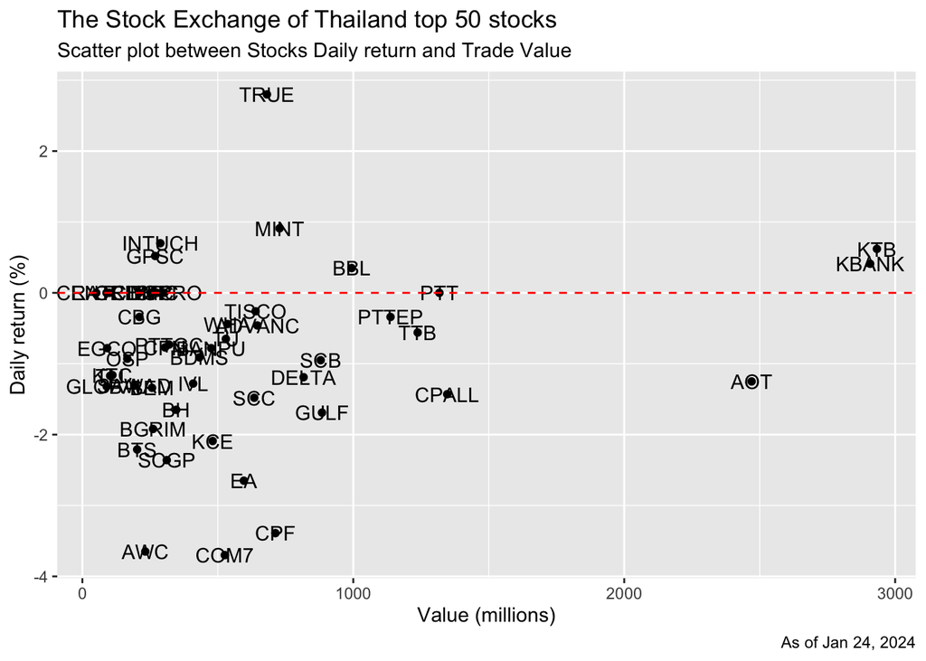

```r
set50df %>% ggplot(mapping = aes(x = Value, y = DailyRetrun, label = Symbol)) +
              geom_point() +
              geom_text() +
              geom_hline(yintercept = 0, color = "red", linetype = "dashed") +
              labs(title = ("The Stock Exchange of Thailand top 50 stocks"),
                   subtitle = ("Scatter plot between Stocks Daily return and Trade Value"),
                   caption = ("As of Jan 24, 2024")) +
              xlab("Value (millions)") +
              ylab("Daily return (%)")
```

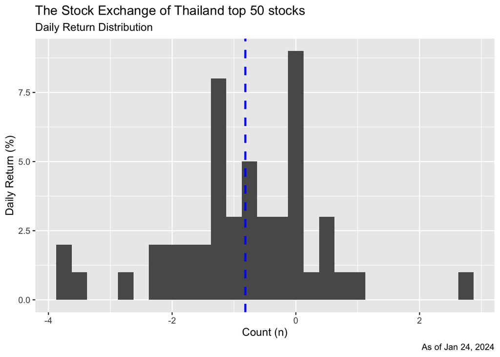

```r
set50df %>% ggplot(data = set50df, mapping = aes(x = DailyRetrun)) +
              geom_histogram(binwidth = 0.25) +
              geom_vline(mapping = aes(xintercept = mean(DailyRetrun)),
                         color = "blue",
                         linetype = "dashed",
                         size = 1) +
              labs(title = ("The Stock Exchange of Thailand top 50 stocks"),
                   subtitle = ("Daily Return Distribution"),
                   caption = "As of Jan 24, 2024") +
              xlab("Count (n)") +
              ylab("Daily Return (%)")
```

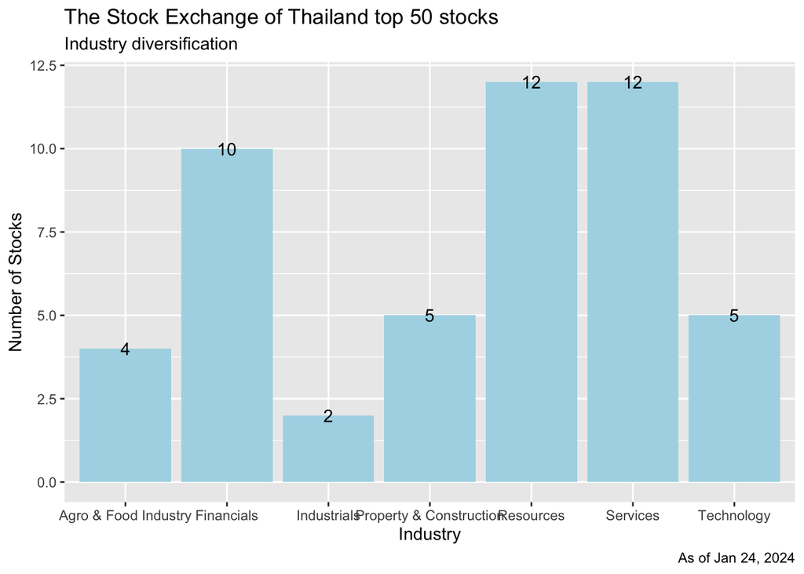

```r
set50Inddf4 %>% ggplot(mapping=aes(x=Industry, y=NumberOfStocks, label = NumberOfStocks)) +
                  geom_col(fill = "lightblue") +
                  geom_text() +
                  labs(title = ("The Stock Exchange of Thailand top 50 stocks"),
                       subtitle = ("Industry diversification"),
                       caption = "As of Jan 24, 2024") +
                  ylab("Number of Stocks")
```

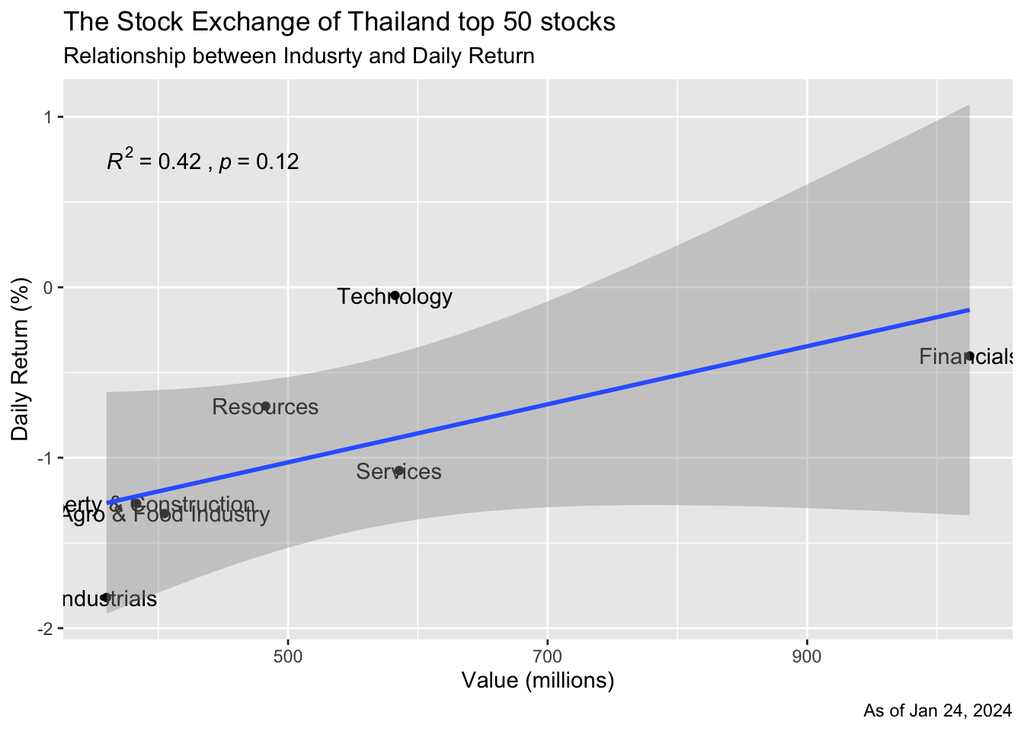

```r
set50Inddf4 %>% ggplot(mapping = aes(x = AvgValue, y = AvgReturn, label = Industry)) +
                  geom_point() +
                  geom_text() +
                  geom_smooth(method = "lm", formula = y~x) +
                  stat_cor(label.y = 0.75,
                           mapping = aes(label = paste(..rr.label.., ..p.label.., sep = "~`,`~"))) +
                  labs(title = ("The Stock Exchange of Thailand top 50 stocks"),
                       subtitle = ("Relationship between Indusrty and Daily Return"),
                       caption = "As of Jan 24, 2024") +
                  xlab("Value (millions)") +
                  ylab("Daily Return (%)")
```